# Lecture 22 R Demo – Longitudinal Data and Time Series

Zach Branson

April 13, 2020

# Time series data

## Structure and basic plots

A **time series** measures a single variable over many points in time. Time intervals may be regularly or irregularly spaced, but we’ll only consider regularly-spaced data today. We’ll focus on visualizing a single variable over time, since there are already so many choices and information to work with.

For this demo, we’re going to work with a dataset that’s actually already loaded when you start `R`: It’s defined under `co2`, and known as the “Mauna Loa Atmospheric CO2 Concentration” dataset. This dataset contains 468 monthly measurements of CO2 concentration from 1959 to 1997.

When you start `R`, if you type in `co2`, this is what you’ll see:

```r
co2
```

```
##         Jan    Feb    Mar    Apr    May    Jun    Jul    Aug    Sep    Oct
## 1959 315.42 316.31 316.50 317.56 318.13 318.00 316.39 314.65 313.68 313.18
## 1960 316.27 316.81 317.42 318.87 319.87 319.43 318.01 315.74 314.00 313.68
## 1961 316.73 317.54 318.38 319.31 320.42 319.61 318.42 316.63 314.83 315.16
## 1962 317.78 318.40 319.53 320.42 320.85 320.45 319.45 317.25 316.11 315.27
## 1963 318.58 318.92 319.70 321.22 322.08 321.31 319.58 317.61 316.05 315.83
## 1964 319.41 320.07 320.74 321.40 322.06 321.73 320.27 318.54 316.54 316.71
## 1965 319.27 320.28 320.73 321.97 322.00 321.71 321.05 318.71 317.66 317.14
## 1966 320.46 321.43 322.23 323.54 323.91 323.59 322.24 320.20 318.48 317.94
## 1967 322.17 322.34 322.88 324.25 324.83 323.93 322.38 320.76 319.10 319.24
## 1968 322.40 322.99 323.73 324.86 325.40 325.20 323.98 321.95 320.18 320.09
## 1969 323.83 324.26 325.47 326.50 327.21 326.54 325.72 323.50 322.22 321.62
## 1970 324.89 325.82 326.77 327.97 327.91 327.50 326.18 324.53 322.93 322.90
## 1971 326.01 326.51 327.01 327.62 328.76 328.40 327.20 325.27 323.20 323.40
## 1972 326.60 327.47 327.58 329.56 329.90 328.92 327.88 326.16 324.68 325.04
```

[output cut: 65 more lines]

These numbers are expressed in parts per million (ppm) - if you’ve taken a chemistry class at CMU (which I haven’t), I assure you know more about this than I do, but ppm is a very common measure for pollutants and contaminants.

The `co2` object is actually defined with a class we haven’t seen yet, `ts` (time series):

```r
class(co2)
```

```
## [1] "ts"
```

As a result, it contains extra attributes about the times associated with each value, and base `R` graphs can plot this automatically (we don’t need to specify the time range manually):

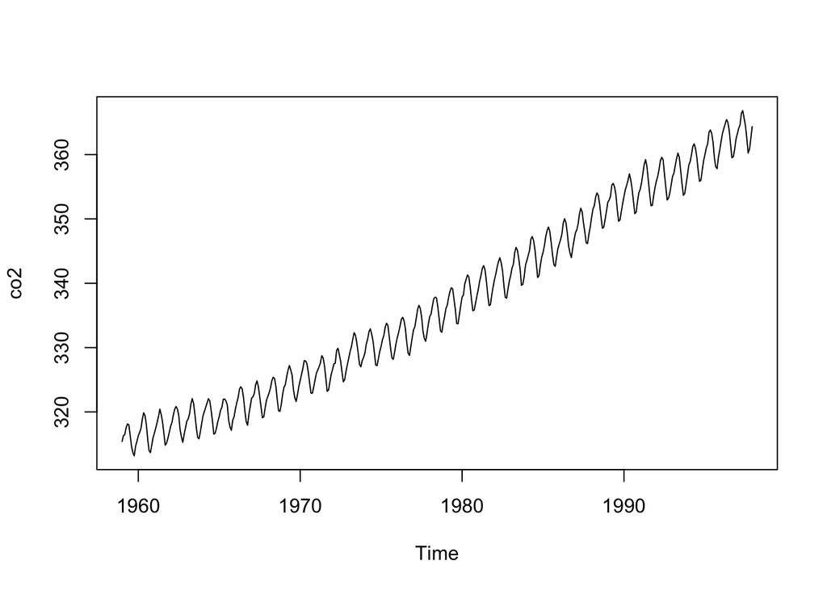

```r
plot(co2)
```

This is typically called a line plot. If you’re very much married to `ggplot`, here’s how you would plot the same data in the `gg` style (note that you need the package `ggfortify` to do this):

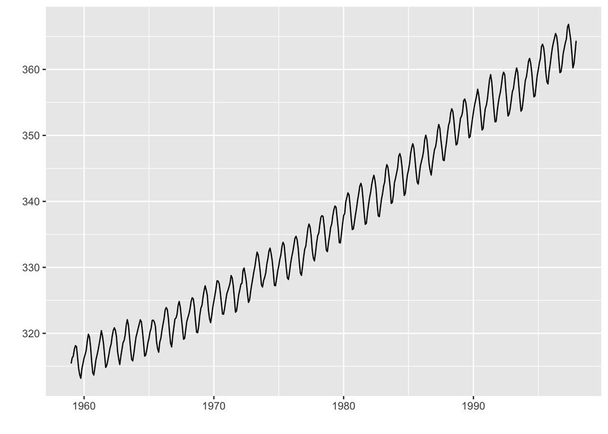

```r
library(ggfortify)
autoplot(co2)
```

In time series, we are interested in checking for trends (does the variable tend to increase or decrease over time?), seasonality (are there tendencies that regularly occur? If so, at what intervals do they occur?), general variability (i.e., variation beyond average trends and seasonality), and outliers (unusual spikes or valleys). Which of these do we see in the `co2` data?

In order to show you more general-purpose plotting methods, we’ll treat `co2` as `numeric` instead of `ts` from now on. This is actually the form that many time series data take (unfortunately, they’re usually not in the nice `ts` format), so this will also show you some of the formatting/structuring issues you’ll have to work with in the wild.

In the code below, we create a dataset with 1:468 as the $x$ variable (x-axis variable) and the CO2 concentration as the $y$ variable (y-axis) variable. Then, we use our usual `ggplot` to plot the data:

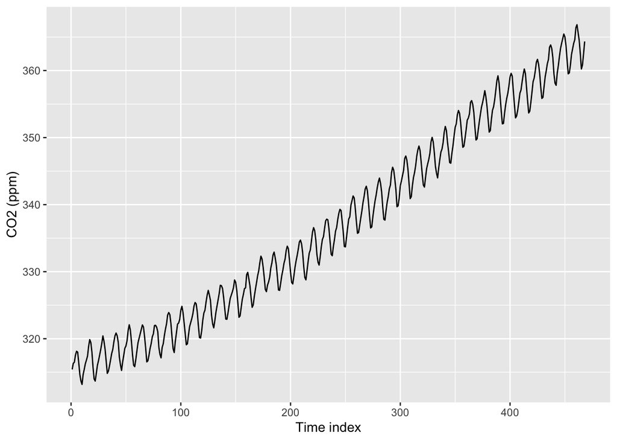

```r
CO2 <- data.frame(x = 1:length(co2),
                  y = as.numeric(co2))
ggplot(CO2, aes(x, y)) + geom_line() + labs(x = "Time index", y = "CO2 (ppm)")
```

Note the x-axis: This will not be helpful/informative to readers. It’s a *super common* mistake for people to just put something like “index” on the x-axis, but they don’t even tell you what they are indexing. Be sure to not make this mistake! To properly structure time series data and label it correctly, you’ll need to know how to work with `Date` type objects in `R` (which we now discuss).

## Formatting `Date` data in R

The following code redefines $x$ in our dataset to be the monthly dates 1/1/1959, 2/1/1959, … , 12/1/1997 using the `as.Date()` function:

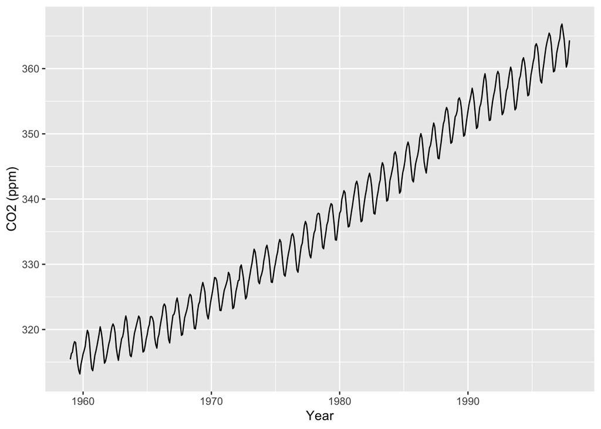

```r
CO2$x = seq(as.Date("1959/1/1"),
                          by = "month", length.out = nrow(CO2))
ggplot(CO2, aes(x, y)) + geom_line() + labs(x = "Year", y = "CO2 (ppm)")
```

Unfortunately, the default format for dates in `as.Date()` is Year/Month/Day. If you prefer another format, such as the common Month/Day/Year (as I used above), you need to include the `format` argument within `as.Date()`, as such (**note that the Y is capitalized - yes, `as.Date()` is that picky**):

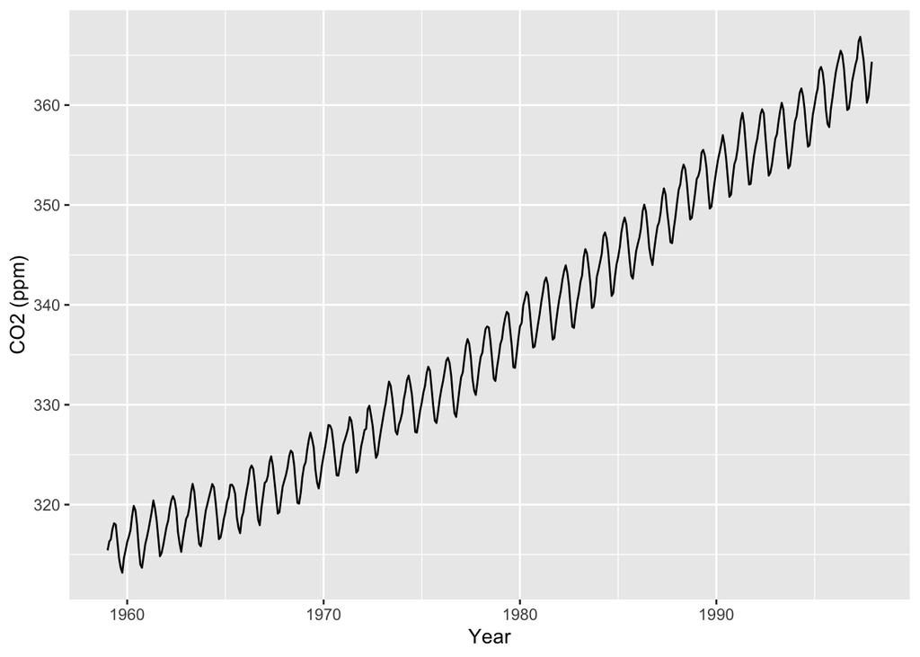

```r
CO2$x = seq(as.Date("1/1/1959", format = "%m/%d/%Y"),
                          by = "month", length.out = nrow(CO2))
ggplot(CO2, aes(x, y)) + geom_line() + labs(x = "Year", y = "CO2 (ppm)")
```

Note that all we needed to do was convert the $x$ variable to a “Date” class, and then we could use `ggplot` as is. This is because `ggplot` knows to use a special date scale for the x-axis when x has class “Date”. As a result, we can easily play with the breaks on the date axis using `scale_x_date()`. For example:

- For a subset of the data, maybe we only want ticks every 4 months, using `date_breaks`.
- We can specify the format of the date with `date_labels`. (See Details section of `?strftime` for the formatting options. Here, we choose abbreviated month `%b` and full year `%Y`.)

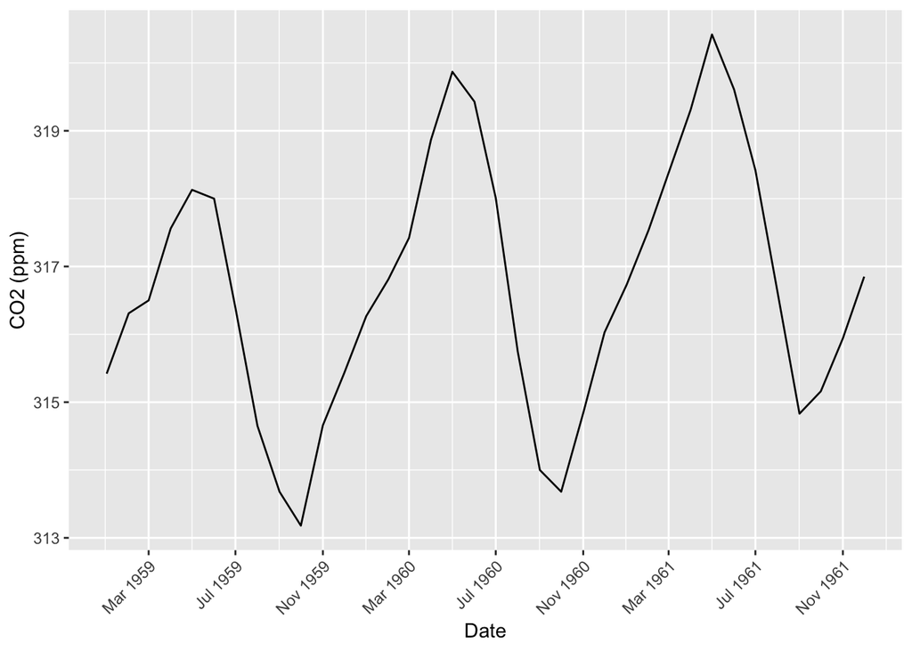

```r
ggplot(CO2[1:36, ], aes(x, y)) + geom_line() + labs(x = "Date", y = "CO2 (ppm)") +
  scale_x_date(date_breaks = "4 months", date_labels = "%b %Y") +
  theme(axis.text.x = element_text(angle = 45, hjust = 1))
```

# Moving window averages

One of the things we look for in time series data are trends. But measurements can be quite noisy, making it hard to see the underlying trend. For example: Most investors probably shouldn’t react by selling or buying every time the stock market jumps up or down a little bit, but it might make sense to respond to a longer-term underlying trend.

As we discussed in lecture, moving averages are a great way to get an idea of underlying trends. The `ggseas` package has a function called `stat_rollapplyr()` for computing moving averages. Below is an example of computing (and displaying) a moving average using this function:

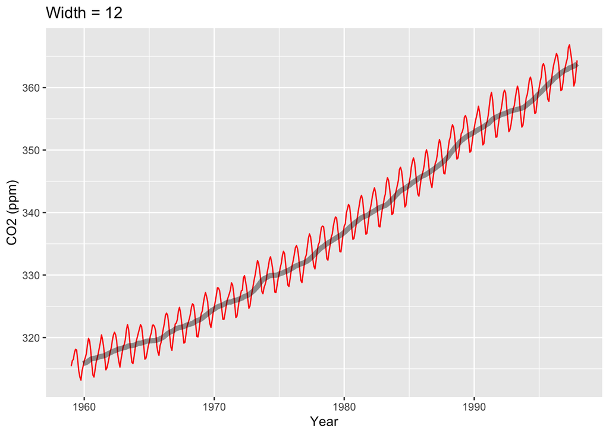

```r
library(tidyverse)
library(ggseas)
ggplot(CO2, aes(x, y)) + geom_line(color="red") + labs(x = "Year", y = "CO2 (ppm)") +
  stat_rollapplyr(width = 12, align = "right", size = 2, alpha=.4) +
  ggtitle("Width = 12")
```

Let’s look at the `stat_rollapplyr()` line more closely. Setting `width = 12` and `align = "right"` states, “For each point, plot the average of that point and the 11 points behind it.” Since this is monthly data, this is the average of a year’s worth of data. Given this, think about why there is no trend line for the first 11 points on the left-hand side of the graph.

To get a better idea of what happens when we change the `width` argument, below is an example of setting `width = 2` and `width = 24`.

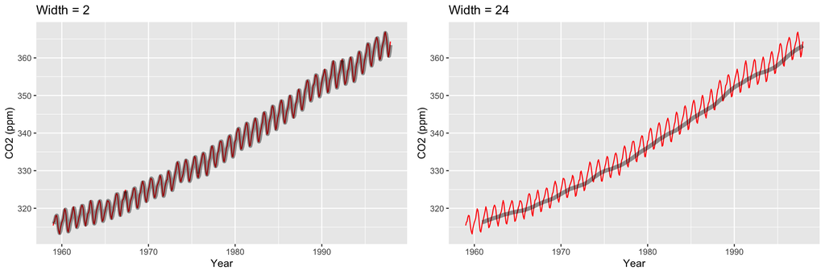

```r
library(gridExtra)
wid2 <- ggplot(CO2, aes(x, y)) + geom_line(color="red") + labs(x = "Year", y = "CO2 (ppm)") +
  stat_rollapplyr(width = 2, align = "right", size = 2, alpha=.4)+
  ggtitle("Width = 2")

wid24 <- ggplot(CO2, aes(x, y)) + geom_line(color="red") + labs(x = "Year", y = "CO2 (ppm)") +
  stat_rollapplyr(width = 24, align = "right", size = 2, alpha=.4) +
  ggtitle("Width = 24")

grid.arrange(wid2, wid24, nrow=1)
```

Setting `width` to be smaller gives us a line that fits the data much better, but it’s also much less smooth. (In fact, setting `width = 1` is literally the data itself.) Meanwhile, setting `width` to be larger gives us a much smoother fit, but it doesn’t fit the data as precisely. Ultimately, choosing how much smoothness you want for your visual is very much an art: You want the trend to be smooth enough that you get an idea of the overall trend, but you also don’t want to deviate from your data too much. Some choices are better than others: For example, below is a trend line whose `width` is obviously too large (obviously because the trend line doesn’t fit the data well at all).

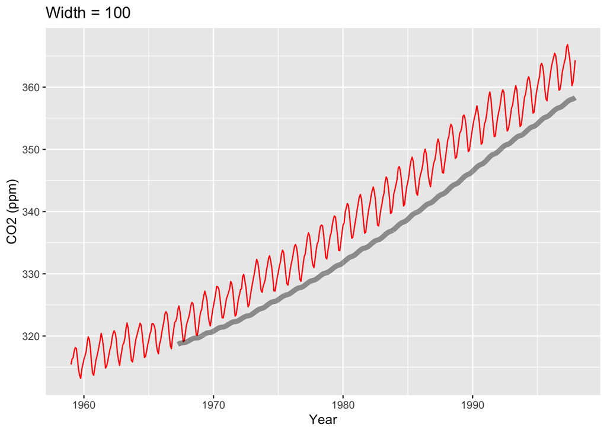

```r
ggplot(CO2, aes(x, y)) + geom_line(color="red") + labs(x = "Year", y = "CO2 (ppm)") +
  stat_rollapplyr(width = 100, align = "right", size = 2, alpha=.4) +
  ggtitle("Width = 100")
```

# Lags and autocorrelation functions

Now we will walk through how to compute autocorrelations using lags.

Imagine computing the autocorrelation at each lag (1, 2, 3, …). For example, the autocorrelation at lag 1 is the correlation between the time series itself and the time series shifted back one timepoint. Computing the autocorrelation at each lag will thus give us a vector of autocorrelations, commonly called the **autocorrelation function** (ACF).

You can think of the ACF as taking in a lag $\ell$ and spitting out a correlation between -1 and 1. The higher the correlation, the more dependent the time series measurements are on each other; and the larger the $\ell$ with high correlation, the more this dependence “lasts” over time.

Base `R` has the `acf()` function which can be used to compute and plot the ACF for a large number of lags.

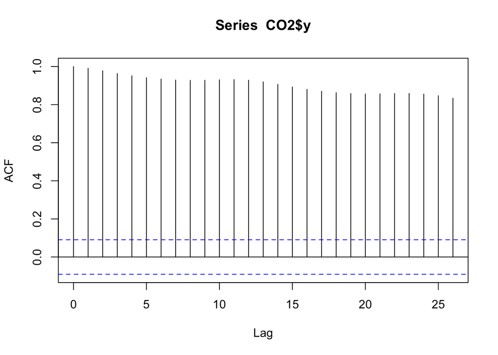

```r
acf(CO2$y)
```

And the `ggplot` version is:

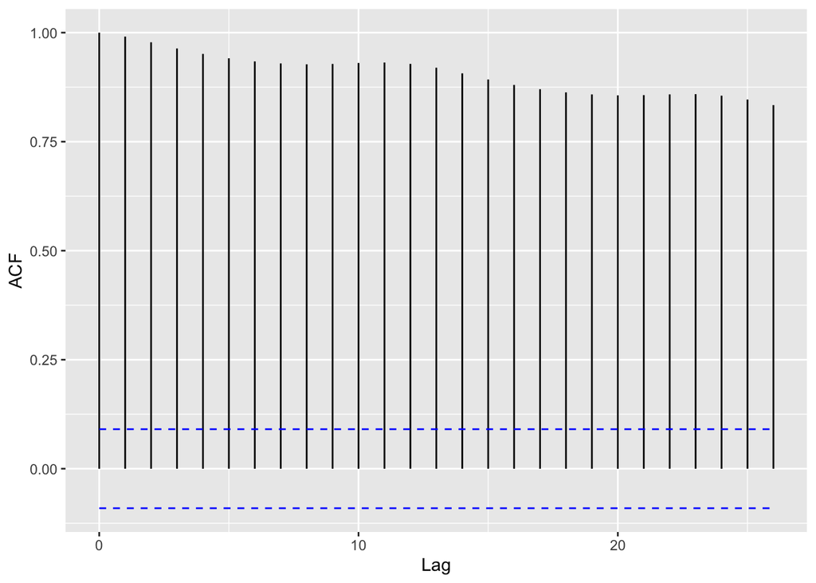

```r
autoCorr = acf(CO2$y, plot = FALSE)
autoplot(autoCorr)
```

By default, these plots display 95% confidence intervals, where autocorrelations outside this confidence interval are deemed “unusually large.” These intervals will depend on the data itself (for example, in another application, the intervals may not be $\pm 0.1$), and the way these intervals are computed is outside the scope of this class (but it is easily Googleable for those interested; see the end of [this document](https://www.itl.nist.gov/div898/handbook/eda/section3/autocopl.htm) for example).

Because the autocorrelations are way above the confidence interval, we would say that this visual clearly shows that the `co2` data is highly autocorrelated, due to the strong global trend. What if we remove the trend, then look at the ACF of the residuals? We can compute moving averages using `rollapply` (in the `zoo` package, loaded when you load `ggseas`).

```r
# Use rollapply to compute a Moving Average,
# then compute residuals (y - MA)
CO2 <- mutate(CO2,
              MA = zoo::rollapply(y,
                             width = 12, FUN = "mean", align = "right", fill = NA),
              res = y - MA)
#Just to understand what this is doing, let's look
#at the first few rows of the data:
CO2[1:13,]
```

```
##             x      y       MA        res
## 1  1959-01-01 315.42       NA         NA
## 2  1959-02-01 316.31       NA         NA
## 3  1959-03-01 316.50       NA         NA
## 4  1959-04-01 317.56       NA         NA
## 5  1959-05-01 318.13       NA         NA
## 6  1959-06-01 318.00       NA         NA
## 7  1959-07-01 316.39       NA         NA
## 8  1959-08-01 314.65       NA         NA
## 9  1959-09-01 313.68       NA         NA
## 10 1959-10-01 313.18       NA         NA
## 11 1959-11-01 314.66       NA         NA
## 12 1959-12-01 315.43 315.8258 -0.3958333
## 13 1960-01-01 316.27 315.8967  0.3733333
```

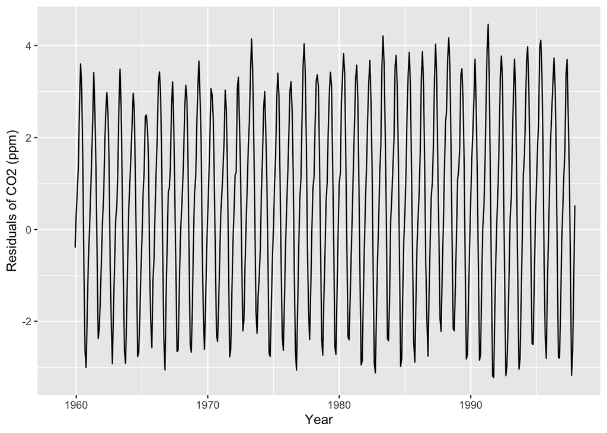

```r
# Plot the residuals
ggplot(CO2, aes(x, res)) + geom_line() +
  labs(x = "Year", y = "Residuals of CO2 (ppm)")
```

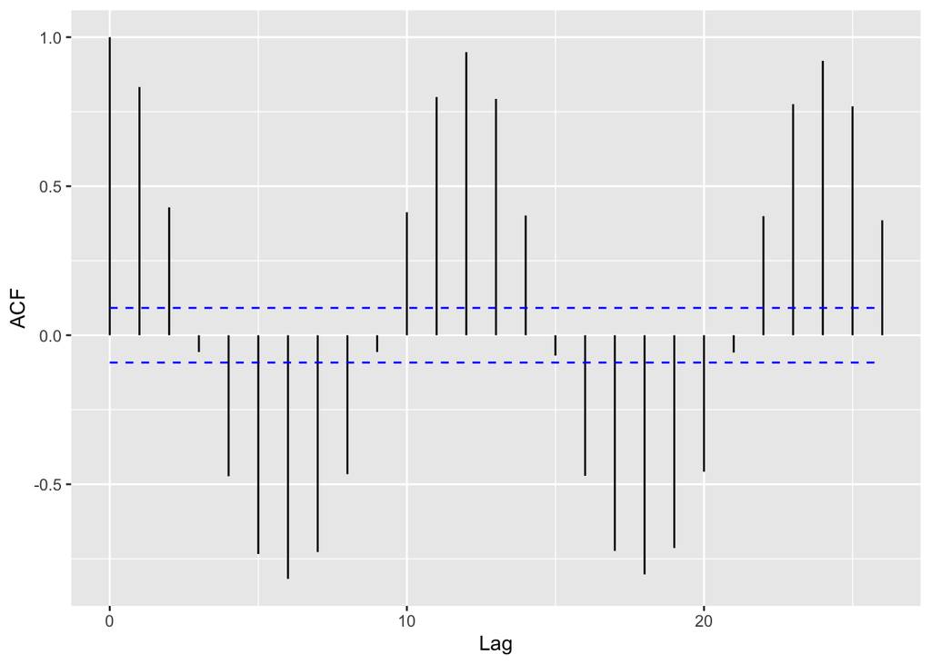

```r
# Compute ACF of the residuals
# (except the first 11 cases, which are NA)
autoplot(acf(tail(CO2$res, -11), plot=F))
```

Now what pattern do we see in the ACF plot? Which lags have the most positive and most negative values? What does this mean for monthly data?

See [this link](https://stackoverflow.com/questions/17788859/acf-plot-with-ggplot2-setting-width-of-geom-bar) for tips on mimicking the `acf()` plot in `ggplot`. For example, you can save the output of `acf()` and then put it inside a data frame:

```r
CO2_acf <- acf(tail(CO2$res, -11))
```

[output not shown]

```r
CO2_acf_df <- with(CO2_acf, data.frame(lag, acf))
#the resulting data.frame looks like this:
head(CO2_acf_df)
```

```
##   lag         acf
## 1   0  1.00000000
## 2   1  0.83287000
## 3   2  0.42898732
## 4   3 -0.05635883
## 5   4 -0.47308749
## 6   5 -0.73412921
```

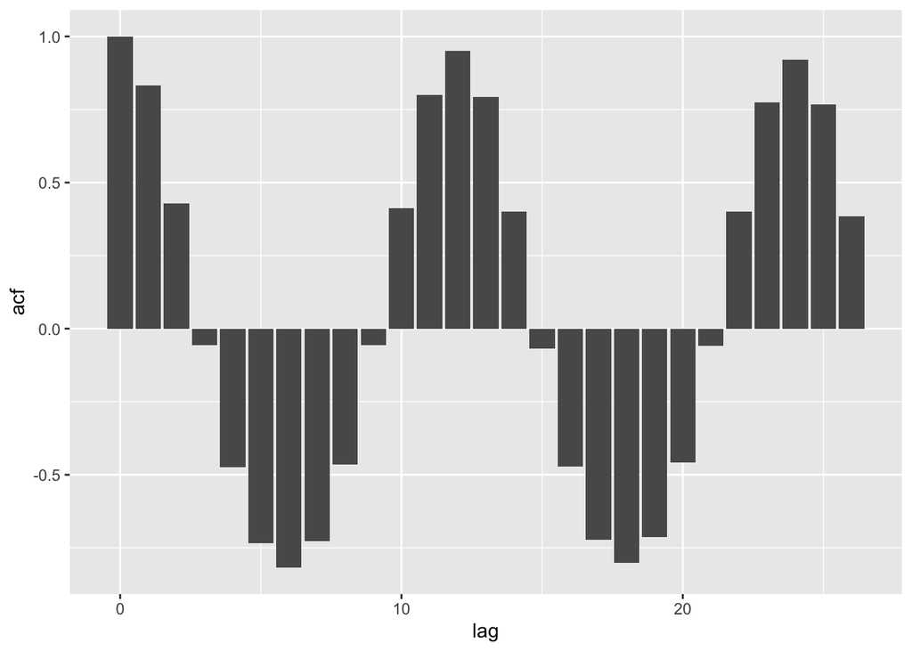

```r
#Then, we can make a simple "bar" plot:
#(bar is in quotes because it's not displaying a categorical variable)
ggplot(CO2_acf_df, aes(x = lag, y = acf)) + geom_bar(stat="identity")
```

```r
#Alternatively, you could use:
# ggplot(CO2_acf_df, aes(x = lag, y = acf)) + geom_col()
#which does the same thing.
```

# Seasonal decomposition

The idea above shows us that we can remove global trends from the dataset and then look for seasonal trends. The base `R` function `stl()` does this explicitly using loess smoothers: “**S**easonal decomposition of **T**ime series by **L**oess”. It actually also separates the seasonal trend from the irregular / residual noise.

In `ggseas`, we can mimic this by using `ggsdc()` instead of starting with the `ggplot()` function. (The argument `s.window` is a kind of loess smoother span for the seasonal extraction.)

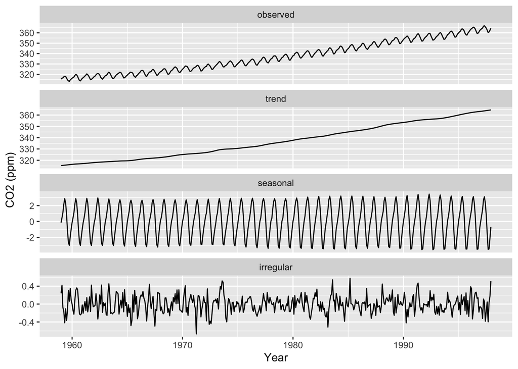

```r
ggsdc(CO2, aes(x, y), frequency = 12, method = "stl", s.window = 7) + geom_line() +
  labs(x = "Year", y = "CO2 (ppm)")
```

The sum of “trend” + “seasonal” + “irregular” gives us back the original data, shown in “observed” (the top facet).

Does it look like `stl` found all interesting global or periodic trends, or is there any signal left in the “irregular” component?